# Authors

# Marc Kéry

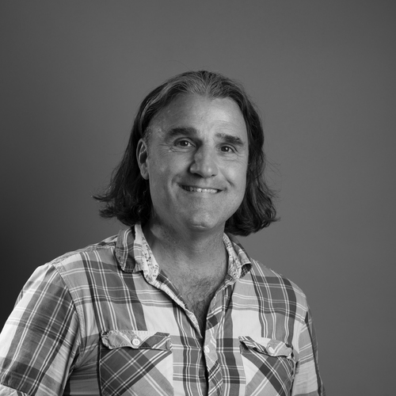

Dr. Kéry works as a senior scientist at the Swiss Ornithological Institute, Sempach, Switzerland. This is a non-profit NGO with about 160 employees dedicated primarily to bird research, monitoring, and conservation. Marc was trained as a plant population ecologist at the Swiss Universities of Basel and Zuerich. After a 2-year postdoc at the (then) USGS Patuxent Wildlife Center in Laurel, MD. During the last 20 years he has worked at the interface between population ecology, biodiversity monitoring, wildlife management, and statistics. He has published more than 100 peer-reviewed journal articles and five textbooks on applied statistical modeling. He has also been very active in teaching fellow biologists and wildlife managers the concepts and tools of modern statistical analysis in their fields in workshops all over the world, something which goes together with his books, which target the same audiences.

# Ken Kellner

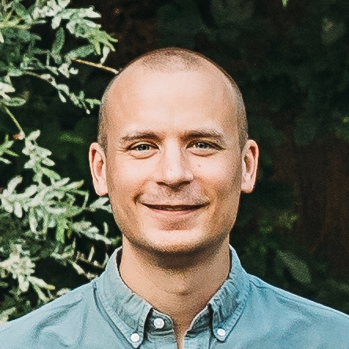

Dr. Kellner is an Assistant Research Professor at Michigan State University, MI, USA. Prior to his current position, he completed a Ph.D. in forest ecology at Purdue University in Indiana, USA, and a postdoc at West Virginia University. Ken’s research has covered a wide range of topics including forest management, plant demography, and avian and mammal conservation. He has published this research in more than 40 peer reviewed publications. In addition, Ken is particularly focused on the development of open-source software tools for ecological modeling. He has developed or contributed to several software packages that are widely used by ecologists and featured in several books, including the successful R packages jagsUI, unmarked, and ubms.